# Tpc_8

Diogo Alexandre Alonso De Freitas

2022-10-15

##### Enunciado

> Num inquérito sobre óculos de sol foram colocadas várias questões aos inquiridos. Para além de características sociodemográficas (sexo, idade e nível de educação), perguntou-se o tipo de óculos de sol que possuíam, quando tinham sido adquiridos, onde tinham sido adquiridos, quanto tinham custado e se eram da marca SoleMio(SM/RB). Para além destas questões, ainda foram colocadas outras que originaram a construção de um conjunto de indicadores, cada um numa escala contínua de 0 a 10 – fatores que influenciam a compra de óculos de sol. Para este TPC, irão apenas analisar duas questões: 1. O indicador “Importância do Preço na compra de óculos de sol” – variável Price; e, 2. a questão “are_RB”, que indica se os óculos são ou não da marca SoleMio Os “Fatores que influenciam a compra de óculos de sol” são variáveis que assumem valores reais no intervalo 0-10, onde 0 corresponde a “nada importante” e 10 corresponde a “extremamente importante”.

```r
def <- readRDS("Estudo_Oculos_Sol.rds")
def
```

| nquest | sex | age | educ | type | when_bought | where_bought | cost | are_RB | nb_own | Pub.Mk | Quality | Ergonomy | Price | Style | Will_buy_RB |
| --- | --- | --- | --- | --- | --- | --- | --- | --- | --- | --- | --- | --- | --- | --- | --- |
| 1 | Male | 38 | Tertiary | Sport style | 2+ years | Optical shop | 200EUR-300EUR | No | 1 | 7.510000 | 7.499758 | 8.447343 | 7.447002 | 8.085599 | Yes |
| 2 | Male | 37 | Tertiary | Classic | 2+ years | Optical shop | 200EUR-300EUR | Yes | 2 | 5.802424 | 8.754736 | 5.557159 | 5.712262 | 7.734740 | Yes |
| 3 | Male | 33 | Tertiary | Classic | Last year | Optical shop | 100EUR-200EUR | No | 1 | 4.756021 | 8.419108 | 7.771410 | 8.305965 | 7.563463 | Maybe |
| 4 | Female | 25 | Profissional | Sport style | Last year | Optical shop | At least 300EUR | No | 3 | 0.910000 | 8.348551 | 8.163167 | 5.792254 | 9.000000 | Yes |
| 5 | Female | 34 | Secondary | Modern | This year | Optical shop | 100EUR-200EUR | No | 3 | 4.661110 | 8.212571 | 6.832928 | 7.942378 | 9.466660 | No |
| 12 | Female | 43 | Profissional | Classic | 2+ years | Optical shop | 100EUR-200EUR | No | 1 | 4.854772 | 8.178145 | 6.116864 | 7.343421 | 8.366720 | NA |
| 13 | Male | 20 | Secondary | Sport style | Last year | Sports shop | Less than 100EUR | No | 1 | 5.804163 | 7.711914 | 6.019403 | 7.377320 | 7.283751 | NA |
| 14 | Male | 22 | Tertiary | Classic | This year | Optical shop | 200EUR-300EUR | No | 3 | 8.000000 | 8.320000 | 7.159109 | 7.000000 | 8.118014 | Maybe |
| 15 | Male | 23 | Profissional | Classic | Last year | Street vendor | Less than 100EUR | No | 1 | 6.900000 | 6.926048 | 6.333070 | 7.719045 | 8.496201 | Maybe |
| 16 | Female | 24 | Tertiary | Modern | This year | Optical shop | 200EUR-300EUR | No | 2 | 5.699232 | 8.456763 | 6.650992 | 6.653646 | 8.243380 | Maybe |

[output cut: 630 more lines]

#### Exercicio 1

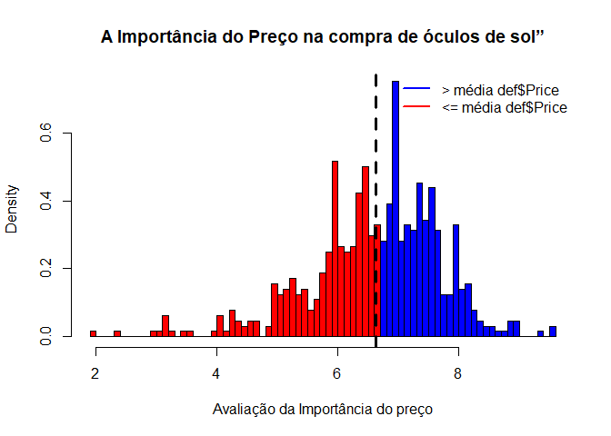

Daqui para a frente, começamos a aplicar as etapas do teste de hipóteses

##### 1.1 - Formulação das hipóteses

> Será que a importância concedida ao preço está, em termos médios, acima do ponto intermédio da escala (i.e. 5) ?

ou seja:

> H0: media <= 5 (hipótese nula)  
> H1: media > 5 (hipótese alternativa)

```r
H0_oculos <- 5
```

> Nota: Temos um teste unilateral à direita

##### 1.2 - Escolher o teste adequado

$$\frac {\overline X - \mu_0}{S'/
\sqrt n} \sim N(0,1)$$

> É um tipo de população normal e não se conhece o respetivo desvio padrão.

##### 1.3 - Estipular o erro máximo que nos permitimos correr ou por outras palavras, através do nível designificância definir a região crítica e não crítica;

```r
significancia <- 0.05
RC_1 <- qnorm(significancia, lower.tail = FALSE)
# Ou então poderiamos usar qt(significancia, length(def$Price)-1) caso a amostra fosse pequena
```

Podemos assim visionar que a região critica situa-se entre:

$$RC= \ [1.6448536, + \infty[$$
Consequentemente, a região não crítica situa-se entre:

$$RNC = \ ]- \infty, 1.6448536[$$

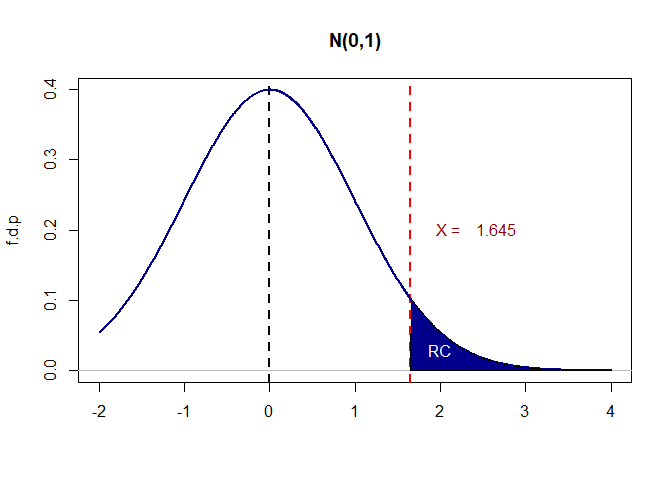

##### 1.4 - Calcular e verificar se o valor do teste(t) está na região crítica ou não

```r
med_preco <- mean(def$Price)
n1_price <- length(def$Price)
sd1 <- sd(def$Price)

t_price <- (med_preco - H0_oculos)/(sd1/sqrt(n1_price))
t_price
```

```
## [1] 38.12991
```

Após calculado *t*, vamos verificar se este se encontra na região critica:

```r
ocu_concl <- t_price < qnorm(significancia, lower.tail = FALSE)
ocu_concl
```

```
## [1] FALSE
```

> Em alternativa a tudo o que fizemos anteriormente, podemos fazer o seguinte:

```r
t.test(def$Price, alternative = "greater", mu = H0_oculos, var.equal = TRUE, conf.level = 1- significancia)
```

```
##
##  One Sample t-test
##
## data:  def$Price
## t = 38.13, df = 639, p-value < 2.2e-16
## alternative hypothesis: true mean is greater than 5
## 95 percent confidence interval:
##  6.553947      Inf
## sample estimates:
## mean of x
##   6.62411
```

##### 1.5 - Tomar a decisão (sem esquecer que nunca se afirma que se aceita a H0: ou a rejeitamos, ou não a rejeitamos)

> Como o valor de t não pertence à região de não rejeição, rejeitamos H0=5,com um nível de significância de 0.05 e consequentemente há razões para crer que a importância concedida ao preço está, em termos médios, acima do ponto intermédio da escala (i.e. 5)

#### Exercicio 2

> Será que homens e mulheres diferem, em termos médios, na importância concedida ao preço? (Suponha que as variâncias do preço nos dois grupos, embora sejam desconhecidas, podem ser consideradas iguais)

```r
masculino_price <- def$Price[which(def$sex == 'Male')]
feminino_price <- def$Price[which(def$sex == 'Female')]
```

##### 2.1 - Formulação das hipóteses

> Será que homens e mulheres diferem, em termos médios, na importância concedida ao preço?

ou seja:

> Ho: u1 - u2 = 0 (hipótese nula)  
> Ha: u1 - u2 $\not=$ 0 (hipótese alternativa)

```r
H0 <- 0
```

> Nota: Temos um Teste Bilateral

##### 2.2 - Escolher o teste adequado

$$\frac {(\overline X_1 - \overline X_2) - (\mu_1 -
\mu_2)_0}{\sqrt{\frac{1}{n_1} + \frac{1}{n_2}} \sqrt{\frac{(n_1 -
1)s_1^{'2} + (n_2 - 1)s_2^{'2}}{n_1+n_2-2}}} \sim N(0,1)$$

> População normal; não se conhece o desvio padrão de ambas as populações, mas assume-se que são o mesmo, ou seja $\sigma^2_1=\sigma^2_2$.

##### 2.3 - Estipular o erro máximo que nos permitimos correr ou por outras palavras, através do nível designificância definir a região crítica e não crítica;

```r
significancia = 0.05/2

n1 <- length(masculino_price)
n2 <- length(feminino_price)

RC <- qt(significancia,n1+n2-2)
# ou
RC <- c(-qt(1-significancia,n1+n2-2), qt(1-significancia,n1+n2-2))
RC
```

```
## [1] -1.963689  1.963689
```

Podemos assim visionar que a região critica situa-se entre:

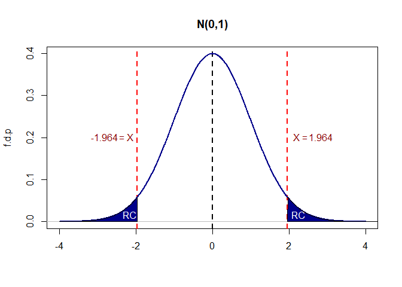

##### 2.4 - Calcular e verificar se o valor do teste(t) está na região crítica ou não

```r
med_masculino=mean(masculino_price)
n_masculino=length(masculino_price)
dp_masculino=sd(masculino_price)

med_feminino=mean(feminino_price)
n_feminino=length(feminino_price)
dp_feminino=sd(feminino_price)

sdd=sqrt(n_masculino**-1+n_feminino**-1)*sqrt(((n_masculino-1)*dp_masculino**2+(n_feminino-1)*dp_feminino**2)/(n_masculino+n_feminino-2))

t <- ((med_masculino-med_feminino) - H0)/sdd

t
```

```
## [1] 1.982582
```

Após calculado *t*, vamos verificar se este se encontra na região critica:

```r
t_dentro<- (t < qt(significancia,n1+n2-2) & t > -qt(significancia,n1+n2-2))
t_dentro
```

```
## [1] FALSE
```

> Em alternativa a tudo o que fizemos anteriormente, podemos fazer o seguinte:

```r
t.test(masculino_price,feminino_price, alternative = "two.sided", mu = H0, var.equal = TRUE, conf.level = 1- significancia)
```

```
##
##  Two Sample t-test
##
## data:  masculino_price and feminino_price
## t = 1.9826, df = 638, p-value = 0.04784
## alternative hypothesis: true difference in means is not equal to 0
## 97.5 percent confidence interval:
##  -0.0224646  0.3597151
## sample estimates:
## mean of x mean of y
##  6.711584  6.542959
```

```r
# ou t.test(dados$Price~dados$sex, alternative="two.sided", var.equal=TRUE)
```

##### EXTRA

```r
library(psych)

describeBy(def$Price,def$sex)
```

```
##
##  Descriptive statistics by group
## group: Female
##    vars   n mean   sd median trimmed  mad min  max range  skew kurtosis   se
## X1    1 332 6.54 1.11   6.77    6.66 0.99 1.9 8.37  6.47 -1.14     1.68 0.06
## ------------------------------------------------------------
## group: Male
##    vars   n mean   sd median trimmed  mad  min  max range  skew kurtosis   se
## X1    1 308 6.71 1.03   6.75    6.73 1.02 3.44 9.54  6.11 -0.13     0.35 0.06
```